# brms example

Johannes Algermissen, Julian Quandt

June 5, 2019

```r
d <- read.csv("https://osf.io/aetq3/download")
d <- droplevels(subset(d, gng_cond != "baseline"))
make_table(head(data.frame(with(d, table(gng_cond, subjectID)))))
```

| gng_cond | subjectID | Freq |
| --- | --- | --- |
| go | 1 | 20 |
| no-go | 1 | 20 |
| go | 2 | 20 |
| no-go | 2 | 20 |
| go | 3 | 20 |
| no-go | 3 | 20 |

```r
make_table(head(data.frame(with(d, table(gng_cond, FoodItem)))))
```

| gng_cond | FoodItem | Freq |
| --- | --- | --- |
| go | 1 | 22 |
| no-go | 1 | 22 |
| go | 2 | 29 |
| no-go | 2 | 26 |
| go | 3 | 29 |
| no-go | 3 | 31 |

```r
contrasts(d$gng_cond) <- contr.sum(2)
d$gng_cond_n <- ifelse(d$gng_cond == "go", 1, -1)
```

# `lme4` Recap

Our aim is to follow a **maximal model approach** here (Barr, Levy, Scheepers, & Tily, 2013). This means that we will try to estimate a *random intercept* for each grouping level, as well as *random slopes* for each fixed effect that we have in the model. Moreover, we want to model the *random correlation* between random slopes and random intercept for each grouping level.

Let us build up the model first, though normally we would usually start with the maximal model immediately:

The observations that we have in this example are nested within participants. This means, each participant contributes multiple observations for each condition. The mixed-model that is consistent with this idea looks like this:

```r
lme_subject <- lmer(diff ~ gng_cond_n
             + (1 + gng_cond_n | subjectID)
             , data = d)
```

In this model the `diff ~ gng_cond_n` part estimates a population-level effect for the difference-score of pre-post measure for each group seperately. By adding the `+(1 + gng_cond_n | subjectID)` we estimate the random effects. The `(1 | subjectID)` estimates the deviation of each participant from the intercept. The `(gng_cond_n| subjectID)` estimates an adjustment on the fixed effects for each participant. To visualize what this means we can create a *caterpillar plot* like the one below:

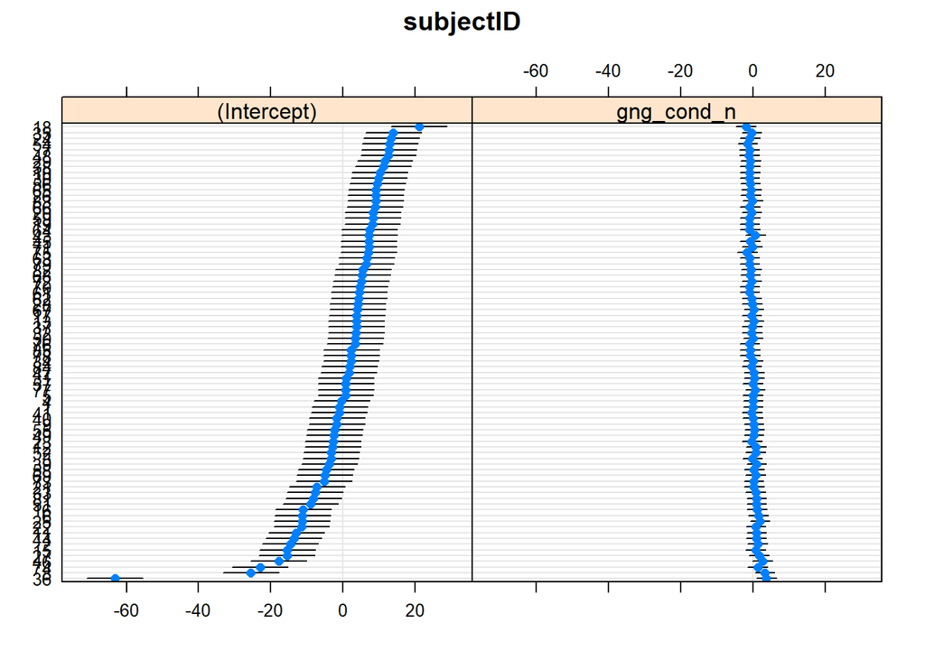

```r
dotplot(ranef(lme_subject, cond.var = TRUE))
```

However, we also have a situation in which each food-picture is randomly divided into multiple conditions across participant (e.g. picture 1 could be in the go-condition for participant 1 but in the no-go condition for participant 2). Thus, each observation for the fixed effect is **cross classified** between participants and food-pictures. Thus we add a second term to the random part of the model acknowleding this end end up with the full model below.

We can fit the maximal model in `lme4` like this:

```r
lme1 <- lmer(diff ~ gng_cond_n
             + (1 + gng_cond_n | subjectID)
             + (1 + gng_cond_n | FoodItem)
             , data = d)
```

Again, we can visualize the random effects.

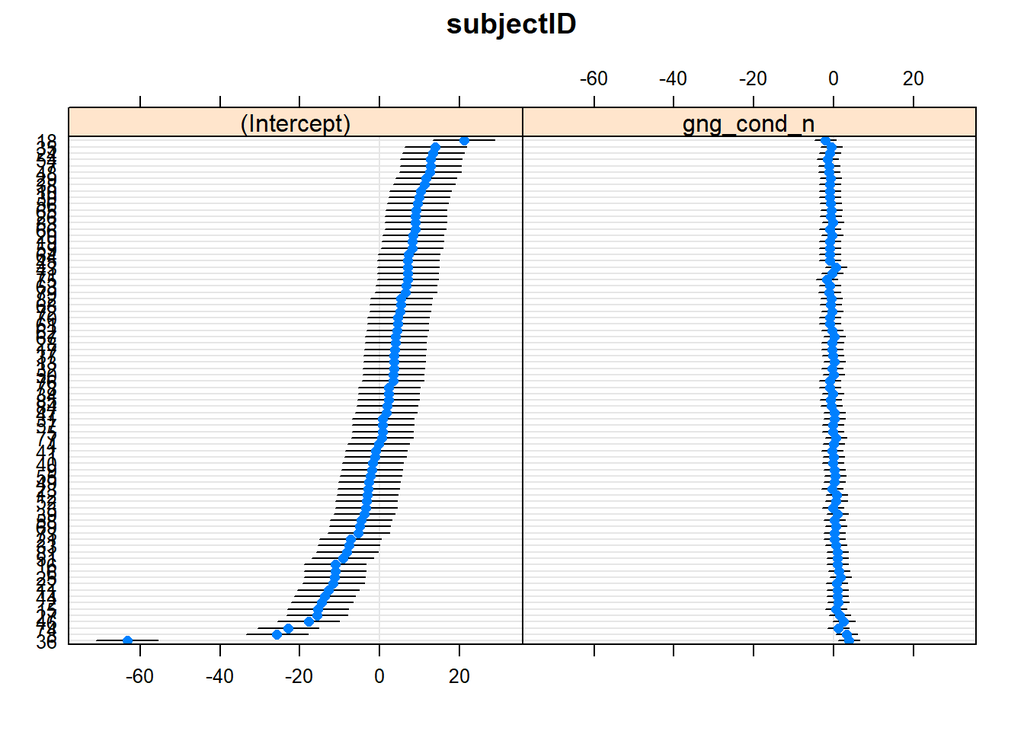

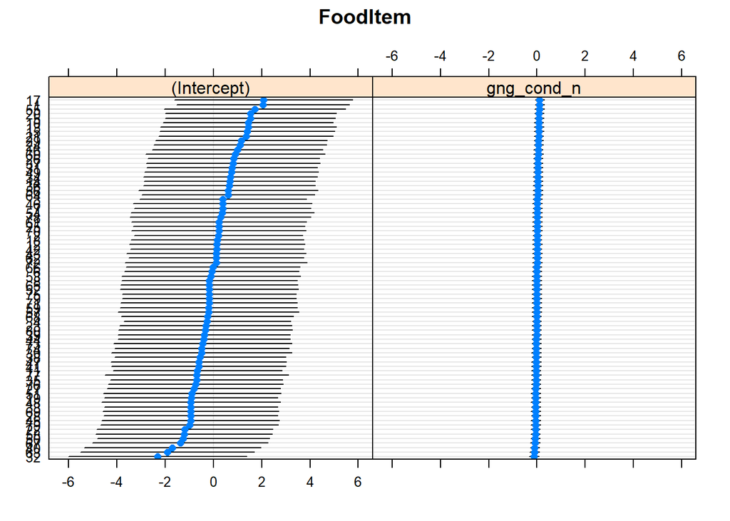

```r
dotplot(ranef(lme1, cond.var = TRUE))
```

We can expect the output of this model with `summary(lme1)`:

```r
summary(lme1)
```

```
## Linear mixed model fit by REML ['lmerMod']
## Formula:
## diff ~ gng_cond_n + (1 + gng_cond_n | subjectID) + (1 + gng_cond_n |
##     FoodItem)
##    Data: d
##
## REML criterion at convergence: 30199.1
##
## Scaled residuals:
##     Min      1Q  Median      3Q     Max
## -5.0070 -0.4762  0.0597  0.5638  4.1351
##
## Random effects:
##  Groups    Name        Variance  Std.Dev. Corr
##  subjectID (Intercept) 148.41074 12.1824
##            gng_cond_n    2.90799  1.7053  -0.56
##  FoodItem  (Intercept)   4.22134  2.0546
##            gng_cond_n    0.01235  0.1111  1.00
##  Residual              689.62266 26.2607
## Number of obs: 3200, groups:  subjectID, 80; FoodItem, 80
##
## Fixed effects:
##             Estimate Std. Error t value
## (Intercept) -11.5931     1.4578  -7.952
## gng_cond_n    2.3095     0.5033   4.589
##
## Correlation of Fixed Effects:
##            (Intr)
## gng_cond_n -0.193
## convergence code: 0
## boundary (singular) fit: see ?isSingular
```

Note that we have a singular fit here, indicating that the model might not be able to estimate one of the parameters correctly as it might be very close to one of the limiting conditions (e.g. a variance very close to 0). Luckily, this will not bother us anymore in `brms`.

# `brms`

Oversimplified, the only thing that we need to do is to exchange the `lmer` for `brm` (which stands for `b`ayesian `r`egression `m`odel).

```r
brm_def <- brm(diff ~ gng_cond_n
             + (1 + gng_cond_n | subjectID)
             + (1 + gng_cond_n | FoodItem)
             , data = d
             , refresh = 0, silent = T)
# refresh = 0, silent = T are normally not used but are convenient if knitting the rmd document
```

However, this only works because there are a lot of hidden default settings that we use in this case. Normally we do not want to leave everything up to the package-developers and want to make the defaults at least explicit and often change them.

The most important defaults that were hidden were:

- the model family
- the priors
- the chain-length and number of chains

If we make them explicit, the model looks like this. Note, that in order to run this model, we would have to specify priors in a `prior_list` collection.

```r
brm1 <- brm(diff ~ gng_cond_n
             + (1 + gng_cond_n | subjectID)
             + (1 + gng_cond_n | FoodItem)
             , data = d
             , family = gaussian()
             , prior = prior_list
             , chains = 4, cores = 4, warmup = 1000, iter = 2000)
```

## Priors

Using the `get_prior` function we can see what the default priors that brms will use in this case would be.

```r
default_priors <- make_table(get_prior(diff ~ gng_cond_n
                                        + (1 + gng_cond_n | subjectID)
                                        + (1 + gng_cond_n | FoodItem)
                                        , data = d))
default_priors
```

| prior | class | coef | group | resp | dpar | nlpar | bound |
| --- | --- | --- | --- | --- | --- | --- | --- |
|  | b |  |  |  |  |  |  |
|  | b | gng_cond_n |  |  |  |  |  |
| lkj(1) | cor |  |  |  |  |  |  |
|  | cor |  | FoodItem |  |  |  |  |
|  | cor |  | subjectID |  |  |  |  |
| student_t(3, -7, 21) | Intercept |  |  |  |  |  |  |
| student_t(3, 0, 21) | sd |  |  |  |  |  |  |
|  | sd |  | FoodItem |  |  |  |  |
|  | sd | gng_cond_n | FoodItem |  |  |  |  |
|  | sd | Intercept | FoodItem |  |  |  |  |
|  | sd |  | subjectID |  |  |  |  |
|  | sd | gng_cond_n | subjectID |  |  |  |  |
|  | sd | Intercept | subjectID |  |  |  |  |
| student_t(3, 0, 21) | sigma |  |  |  |  |  |  |

In this case, 4 different priors are specified:

1. a prior for the Intercept and the effect of go/no-go condition
2. a prior for the random correlations
3. a prior for the standard deviations aka. random effects
4. a prior for the residual variance `sigma`

Things to note here:

You might not expect this, given that these are ‘priors’ and that they are ‘default’ but they *do* depend on the data. The specific intercept prior in this case `student_t(3, -7, 21)` was chosen based on properties of the data at hand. For other data, it will be different!

This might seem odd, someone *has* to specify a prior that is based on *the specific research question* and if you do not do it, Paul Bürkner (the brms head-developer) will do it for you!

All priors, except for the correlation use `student-t` distributions. These are used as they are very *weak* to minimize the ‘influence’ on the results. For example, we can have a look of what the default prior expects about the intercept:

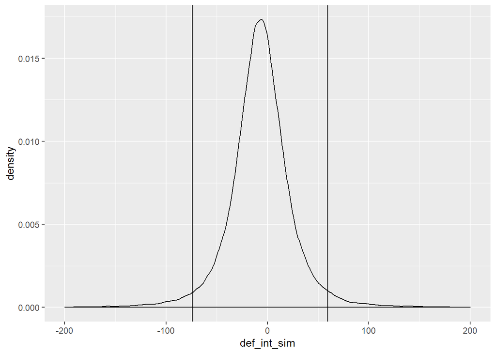

```r
set.seed(1234) # make the random sampling reproducible by setting a seed

def_int_sim <- rstudent_t(1e5, 3, -7, 21)
HDI95_def_int <- unname(quantile(def_int_sim, c(.025, .975)))


ggplot() + geom_density(aes(x = def_int_sim)) + xlim(-200, 200) + geom_vline(xintercept = HDI95_def_int[1]) +  geom_vline(xintercept = HDI95_def_int[2])
```

This plot shows that all this prior ‘dares’ to say is that the intercept (i.e. mean difference score) will most likely be somewhere between -74 and 60. However even values around -1216 or 1029 are not considered impossible. This is not very daring given that the maximum possible difference in this case would between -200 and 200. Thus this prior is very very weak and even with basically *no* expectations of what the difference will be we could do better than this (just by e.g. saying everything outside `[-200, 200]` is impossible.

Specifiying a list of `set_prior` commands, we can change the priors we want, and leave the rest (in this case the correlation) at default by not including it.

```r
prior_list <- c(set_prior('normal(0, 50)', class = 'Intercept'),
                   set_prior('normal(0, 10)', class = 'b'),
                   set_prior('cauchy(0, 5)', class = 'sd')
                   )
```

Lets see how our intercept prior looks now.

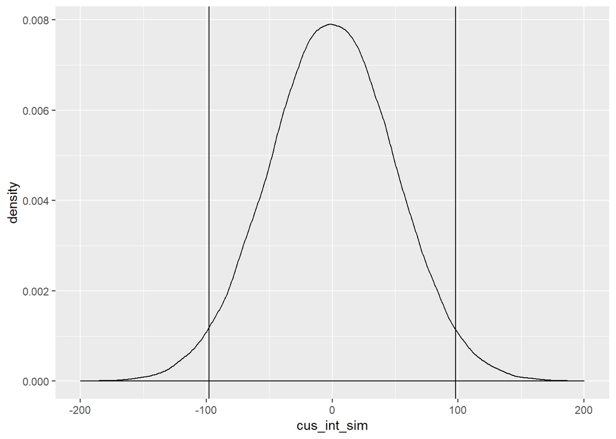

```r
cus_int_sim <- rnorm(1e5, 0, 50)
HDI95_cus_int <- unname(quantile(cus_int_sim, c(.025, .975)))


ggplot() + geom_density(aes(x = cus_int_sim)) + xlim(-200, 200) + geom_vline(xintercept = HDI95_cus_int[1]) +  geom_vline(xintercept = HDI95_cus_int[2])
```

This looks much more reasonable with 95% of the prior density between -98 and 98 and no values below -237 or above 235.

## Fitting the model

```r
brm1 <- brm(diff ~ gng_cond_n
             + (1 + gng_cond_n | subjectID)
             + (1 + gng_cond_n | FoodItem)
             , data = d
             , family = gaussian()
             , prior = prior_list
             , chains = 4, cores = 4, warmup = 1000, iter = 2000
            , save_all_pars = TRUE) # we need save_all_pars for bayes-factors
```

# Diagnostics

Now its time to check whether our model converged. This works differently compared to lme4.

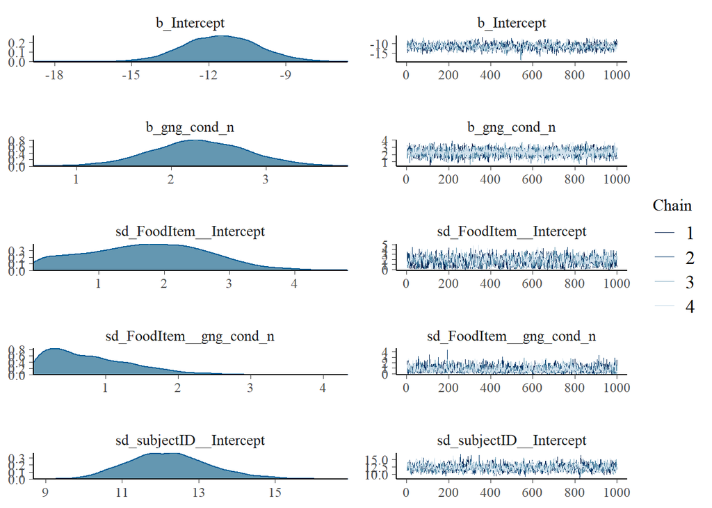

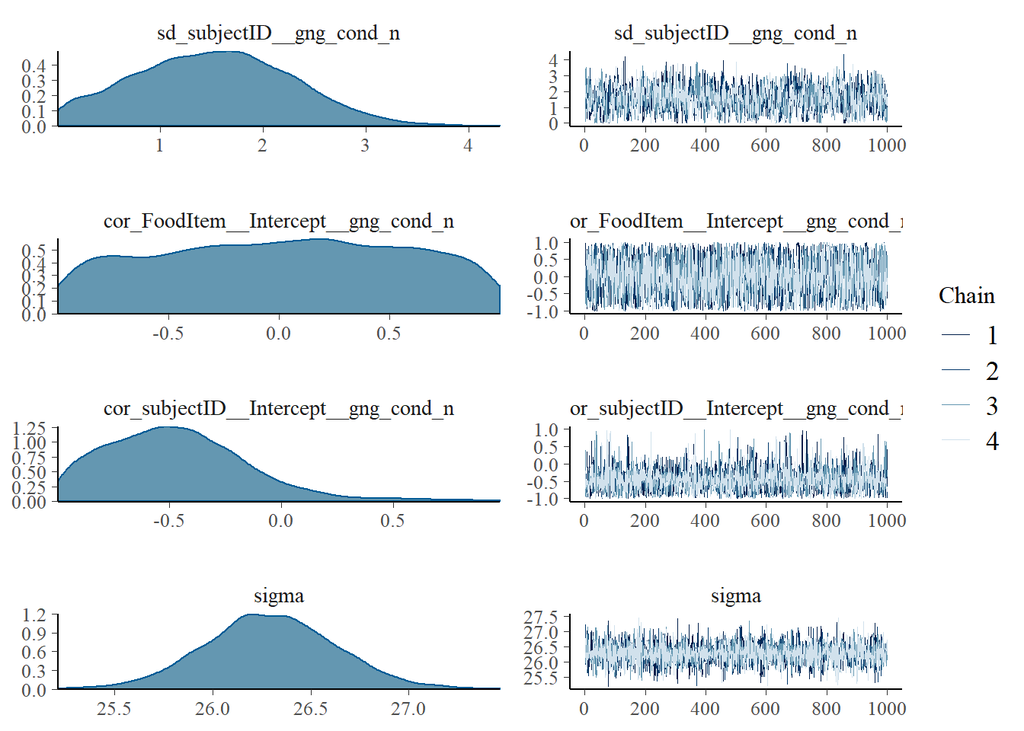

```r
plot(brm1, ask = F)
```

We want to see whether chains look like ‘hairy catterpillars’.

As this is difficult to see here, let’s zoom in on the population-level parameters.

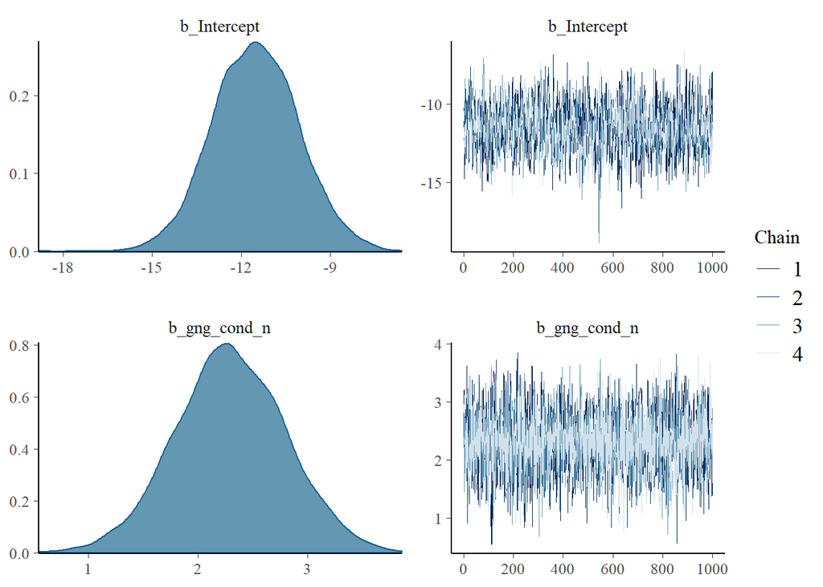

```r
plot(brm1, pars = "^b", ask = F)
```

Next we want to see whether there were any ‘divergent transitions’, i.e. movements of the MCMC sampler through the probability space that are ‘weird’ (it’s quite technical, detailed information is [here](https://mc-stan.org/docs/2_19/reference-manual/divergent-transitions.html)).

```r
options(width = 200)
summary(brm1)
```

```
##  Family: gaussian
##   Links: mu = identity; sigma = identity
## Formula: diff ~ gng_cond_n + (1 + gng_cond_n | subjectID) + (1 + gng_cond_n | FoodItem)
##    Data: d (Number of observations: 3200)
## Samples: 4 chains, each with iter = 2000; warmup = 1000; thin = 1;
##          total post-warmup samples = 4000
##
## Group-Level Effects:
## ~FoodItem (Number of levels: 80)
##                           Estimate Est.Error l-95% CI u-95% CI Eff.Sample Rhat
## sd(Intercept)                 1.72      0.91     0.11     3.48       1224 1.01
## sd(gng_cond_n)                0.78      0.58     0.03     2.14       2167 1.00
## cor(Intercept,gng_cond_n)     0.01      0.55    -0.94     0.94       4293 1.00
##
## ~subjectID (Number of levels: 80)
##                           Estimate Est.Error l-95% CI u-95% CI Eff.Sample Rhat
## sd(Intercept)                12.23      1.08    10.33    14.58       1365 1.00
## sd(gng_cond_n)                1.51      0.76     0.11     3.00       1145 1.00
## cor(Intercept,gng_cond_n)    -0.46      0.33    -0.96     0.34       3638 1.00
##
## Population-Level Effects:
##            Estimate Est.Error l-95% CI u-95% CI Eff.Sample Rhat
## Intercept    -11.51      1.45   -14.37    -8.65       1168 1.00
## gng_cond_n     2.30      0.50     1.30     3.29       5160 1.00
##
## Family Specific Parameters:
##       Estimate Est.Error l-95% CI u-95% CI Eff.Sample Rhat
## sigma    26.29      0.33    25.65    26.95       5848 1.00
##
## Samples were drawn using sampling(NUTS). For each parameter, Eff.Sample
## is a crude measure of effective sample size, and Rhat is the potential
## scale reduction factor on split chains (at convergence, Rhat = 1).
```

Additionally we could have a look at the `pairs()` plot to see whether the samples of the individual paramters look fine (like a round cloud of points)

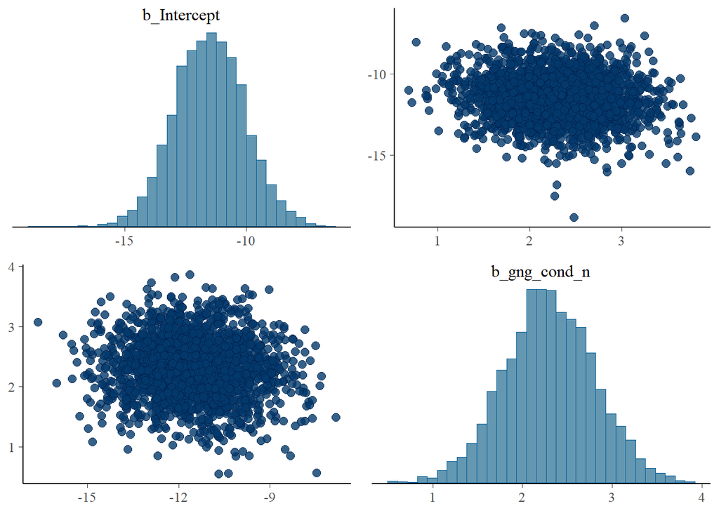

```r
pairs(brm1, pars = "^b")
```

### Non-Convergence

If the model had not converged, we would make some slight changes to the fitting syntax.

1. Increase the chain-length
2. Increase resolution of the HMC-sampler by setting `adapt_delta` to .99

This would work the following way

```r
brm1 <- brm(diff ~ gng_cond_n
             + (1 + gng_cond_n | subjectID)
             + (1 + gng_cond_n | FoodItem)
             , data = d
             , family = gaussian()
             , prior = prior_list
             , chains = 4, cores = 4, warmup = 1000, iter = 5000
            , save_all_pars = TRUE  # we need save_all_pars for bayes-factors
            , control = list(adapt_delta = .99) )
```

More detailed information about this issue can be found in the stan-documentation [here](https://mc-stan.org/misc/warnings.html#divergent-transitions-after-warmup)

# Evaluation

## Adequacy

The model seems to have converged well, but is it an adequate representation of the data? First we can have a look at whether the posterior samples represent the observed data. This is called a posterior-predictive check.

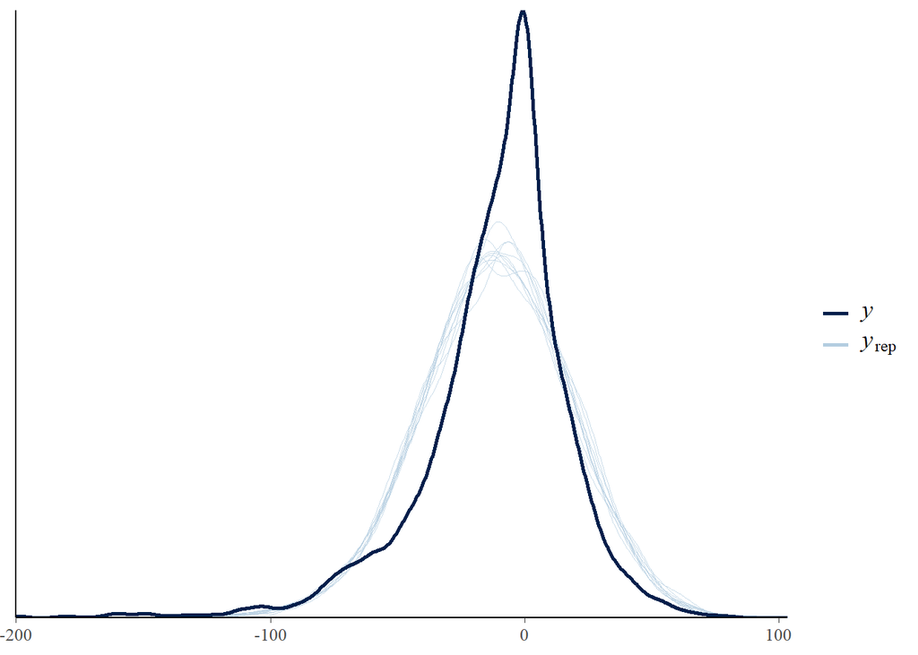

```r
pp_check(brm1)
```

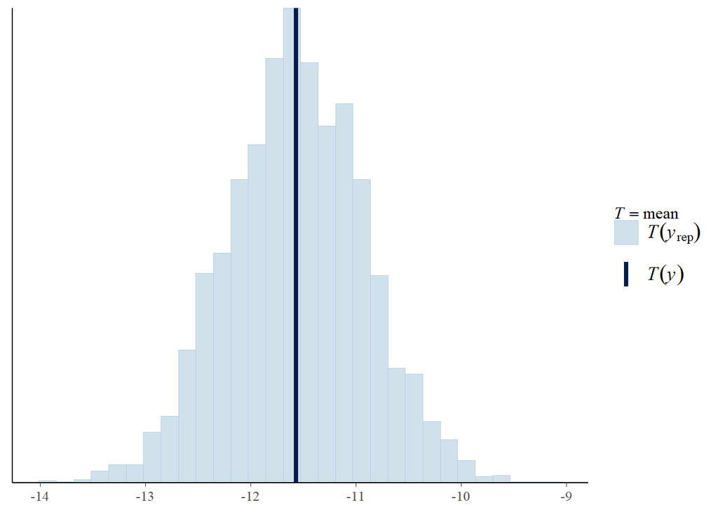

```r
pp_check(brm1, type = "stat")
```

Next we could check for influential observations with help of the `loo` package. `loo` performs approximate leave-one-out cross validation and thereby provides information about the importance of single observations on the model-predictions. If observations have high `PSIS-LOO` statistics (> .7), they are influential and should therefore be investigated further. Moreover, this results in information-criteria not being reliable as they are performing approximate leave-one-out cross validation, that is heavily influenced by influential values. In these cases we could do k-fold cross validation by hand instead.

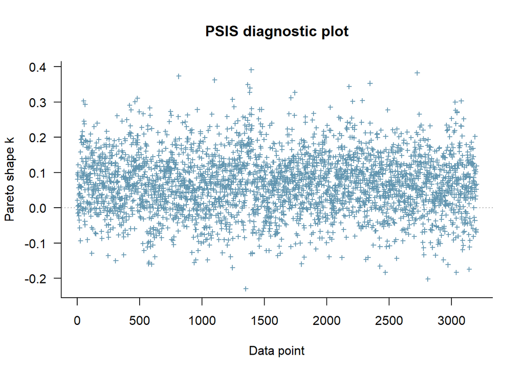

```r
loo_brm1 <- loo(brm1)
plot(loo_brm1)
```

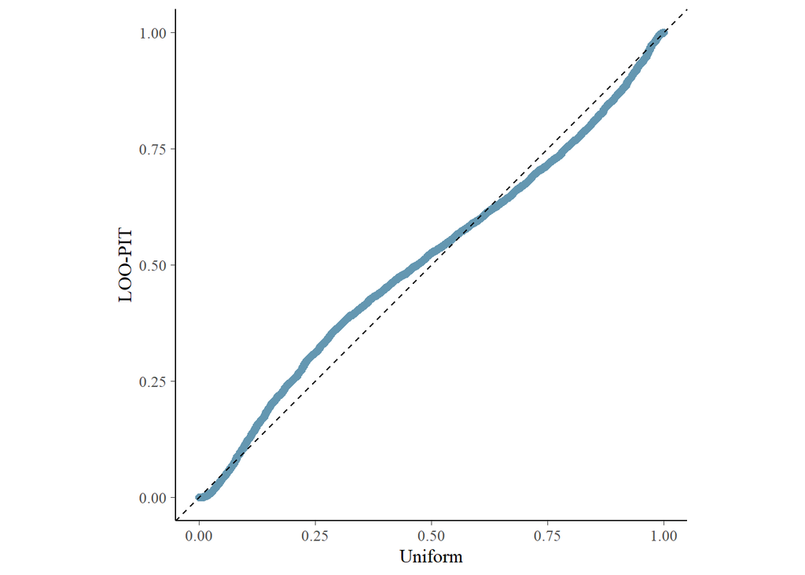

```r
pp_check(brm1, type = "loo_pit")
```

## Estimates

To check our estimates we can look at the summary

```r
summary(brm1)
```

```
##  Family: gaussian
##   Links: mu = identity; sigma = identity
## Formula: diff ~ gng_cond_n + (1 + gng_cond_n | subjectID) + (1 + gng_cond_n | FoodItem)
##    Data: d (Number of observations: 3200)
## Samples: 4 chains, each with iter = 2000; warmup = 1000; thin = 1;
##          total post-warmup samples = 4000
##
## Group-Level Effects:
## ~FoodItem (Number of levels: 80)
##                           Estimate Est.Error l-95% CI u-95% CI Eff.Sample Rhat
## sd(Intercept)                 1.72      0.91     0.11     3.48       1224 1.01
## sd(gng_cond_n)                0.78      0.58     0.03     2.14       2167 1.00
## cor(Intercept,gng_cond_n)     0.01      0.55    -0.94     0.94       4293 1.00
##
## ~subjectID (Number of levels: 80)
##                           Estimate Est.Error l-95% CI u-95% CI Eff.Sample Rhat
## sd(Intercept)                12.23      1.08    10.33    14.58       1365 1.00
## sd(gng_cond_n)                1.51      0.76     0.11     3.00       1145 1.00
## cor(Intercept,gng_cond_n)    -0.46      0.33    -0.96     0.34       3638 1.00
##
## Population-Level Effects:
##            Estimate Est.Error l-95% CI u-95% CI Eff.Sample Rhat
## Intercept    -11.51      1.45   -14.37    -8.65       1168 1.00
## gng_cond_n     2.30      0.50     1.30     3.29       5160 1.00
##
## Family Specific Parameters:
##       Estimate Est.Error l-95% CI u-95% CI Eff.Sample Rhat
## sigma    26.29      0.33    25.65    26.95       5848 1.00
##
## Samples were drawn using sampling(NUTS). For each parameter, Eff.Sample
## is a crude measure of effective sample size, and Rhat is the potential
## scale reduction factor on split chains (at convergence, Rhat = 1).
```

Just for comparison, lets see how much influence the prior had in this case by comparing it to the model with the default (very vague) prior.

```r
summary(brm_def)
```

```
##  Family: gaussian
##   Links: mu = identity; sigma = identity
## Formula: diff ~ gng_cond_n + (1 + gng_cond_n | subjectID) + (1 + gng_cond_n | FoodItem)
##    Data: d (Number of observations: 3200)
## Samples: 4 chains, each with iter = 2000; warmup = 1000; thin = 1;
##          total post-warmup samples = 4000
##
## Group-Level Effects:
## ~FoodItem (Number of levels: 80)
##                           Estimate Est.Error l-95% CI u-95% CI Eff.Sample Rhat
## sd(Intercept)                 1.79      0.94     0.12     3.59        912 1.00
## sd(gng_cond_n)                0.81      0.57     0.04     2.11       2321 1.00
## cor(Intercept,gng_cond_n)     0.04      0.56    -0.94     0.95       3971 1.00
##
## ~subjectID (Number of levels: 80)
##                           Estimate Est.Error l-95% CI u-95% CI Eff.Sample Rhat
## sd(Intercept)                12.38      1.12    10.44    14.82       1225 1.00
## sd(gng_cond_n)                1.56      0.80     0.13     3.15       1214 1.00
## cor(Intercept,gng_cond_n)    -0.47      0.33    -0.97     0.34       2413 1.00
##
## Population-Level Effects:
##            Estimate Est.Error l-95% CI u-95% CI Eff.Sample Rhat
## Intercept    -11.61      1.52   -14.62    -8.60        813 1.00
## gng_cond_n     2.32      0.52     1.32     3.31       5680 1.00
##
## Family Specific Parameters:
##       Estimate Est.Error l-95% CI u-95% CI Eff.Sample Rhat
## sigma    26.28      0.34    25.65    26.93       5876 1.00
##
## Samples were drawn using sampling(NUTS). For each parameter, Eff.Sample
## is a crude measure of effective sample size, and Rhat is the potential
## scale reduction factor on split chains (at convergence, Rhat = 1).
```

And what about lme4?

```r
summary(lme1)
```

```
## Linear mixed model fit by REML ['lmerMod']
## Formula: diff ~ gng_cond_n + (1 + gng_cond_n | subjectID) + (1 + gng_cond_n |      FoodItem)
##    Data: d
##
## REML criterion at convergence: 30199.1
##
## Scaled residuals:
##     Min      1Q  Median      3Q     Max
## -5.0070 -0.4762  0.0597  0.5638  4.1351
##
## Random effects:
##  Groups    Name        Variance  Std.Dev. Corr
##  subjectID (Intercept) 148.41074 12.1824
##            gng_cond_n    2.90799  1.7053  -0.56
##  FoodItem  (Intercept)   4.22134  2.0546
##            gng_cond_n    0.01235  0.1111  1.00
##  Residual              689.62266 26.2607
## Number of obs: 3200, groups:  subjectID, 80; FoodItem, 80
##
## Fixed effects:
##             Estimate Std. Error t value
## (Intercept) -11.5931     1.4578  -7.952
## gng_cond_n    2.3095     0.5033   4.589
##
## Correlation of Fixed Effects:
##            (Intr)
## gng_cond_n -0.193
## convergence code: 0
## boundary (singular) fit: see ?isSingular
```

If we compare the estimates of brms and lme4 they are very similar in this case. One noteworthy thing is the random correlation in the food-item term. Notice how, while in lme4 the estimate reports 1 (which you should read as “cannot be estimated” in this case rather than saying it actually is 1), the brms model will give you a value close to 0. But if you look at the credible interval of that interaction it basically shows that it can be anywhere between -1 and 1. Why is this? Well lets have a look at the prior of the correlation, this `lkj(1)` thing from the table above.

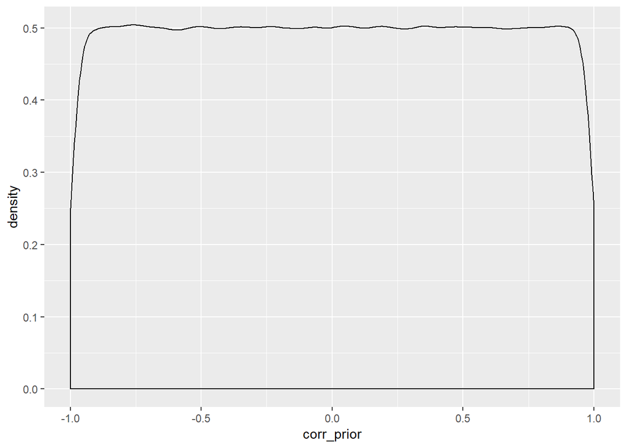

```r
corr_prior <- data.frame(rlkjcorr(1e6, 2, eta = 1))[[2]]
ggplot()+geom_density(aes(x = corr_prior))
```

From this plot, we see that the prior that is used is very vague, basically saying that *any* correlation is equally likely. This is exactly what we get back in the estimates, telling us that the mean is 0 and the 95% CI is between -.95 and .95 approximately. This is not a “bug” or a conincidence and is actually a very important point about priors. If we have a lot of data, the prior that we specify will not really matter as we saw for the other estimates above where the default priors and our own priors led to basically identical estimates, even though they were in fact quite different.

However, for the random correlation we only have few observations. This is the reason why `lme4` rejects to give us an estimate (or rather gives us the uninterpretable 1), as we do have any prior information that we can use and the data do not give us an interpretable answer, therefore it just cannot be estimated. In the Bayesian framework, we already have the prior to work with, saying that it might be anything between -1 and 1, and this is exactly what we get back here.

This is an important point to realize: When we have a lot of data, the prior will not influence the estimates much, but if we do *not* it can still help our inference by allowing us to include terms in the model that we might not have a lot of information on without simplifying the model. In this case, where we want to keep the correlation in there to regularize our inference on the fixed effects but we might not know beforehand whether it can be estimated we can just keep it in and stop worrying about it as the we will just get the prior back when the data are not giving us any new information. This is why most convergence problems in `brms` can simply be solved by increasing chain length or adjusting the step-size of the sampler.

We can also plot the effects in terms of fitted values and predictions.

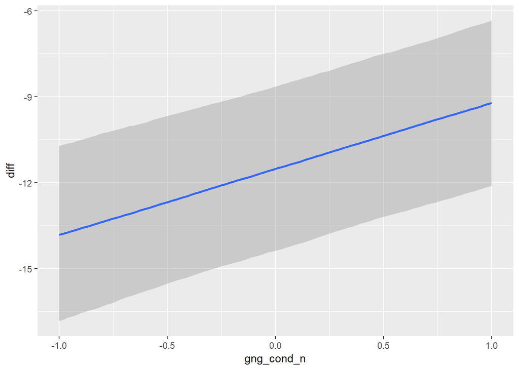

```r
marginal_effects(brm1)
```

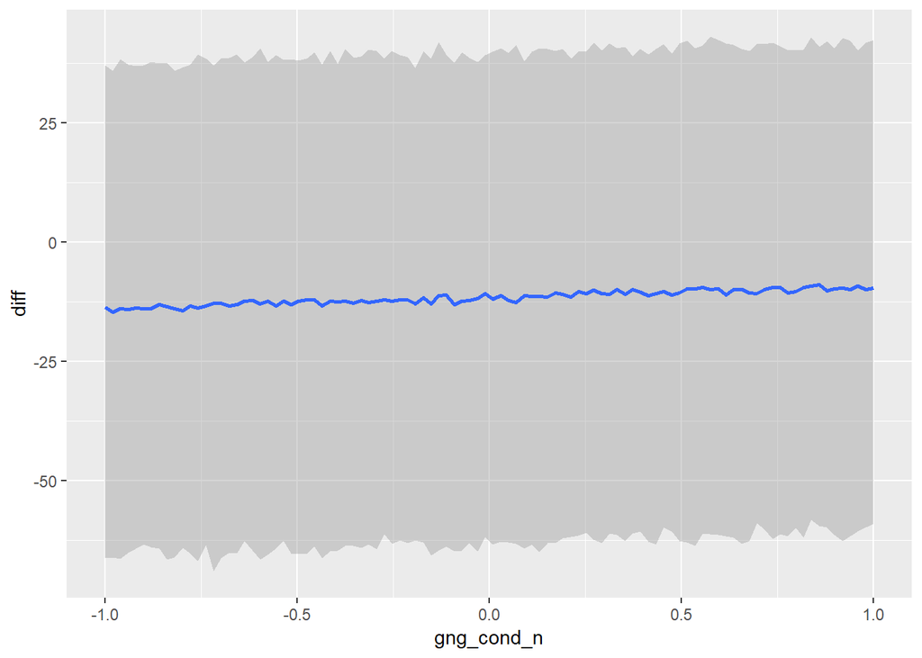

```r
marginal_effects(brm1, method = "predict")
```

Notice that even though there is a clear effect, it is numerically rather small in this case and would not help much in predicting someones score as there is so much noise between observations.

# Model/Effect evaluation

With numeric effects or factors with only 2 levels, we can directly use the posterior as a test for whether an effect is present. We can calculate a Bayesian p-value (the name is confusing it does *not* have the same interpretation as a frequentist p-value)

```r
gng_post <- c(posterior_samples(brm1, pars = "b_gng_cond"))[[1]]
p_val_gng <- mean(gng_post < 0)
p_val_gng
```

```
## [1] 0
```

In this case the p-value would be <.00025 (because it is based on 4000 samples, 1000 per chain; we have 0 observations that would suggest that the effect is in the opposite direction than we would have expected).

```r
prior_list_brm0 <- c(set_prior('normal(0, 50)', class = 'Intercept'),
                   set_prior('cauchy(0, 5)', class = 'sd')
                   )

brm0 <- brm(diff ~ 1
             + (1 + gng_cond_n | subjectID)
             + (1 + gng_cond_n | FoodItem)
             , data = d
             , family = gaussian()
             , prior = prior_list_brm0
             , chains = 4, cores = 4, warmup = 1000, iter = 2000
             , save_all_pars = TRUE) # we need to save pars for bayes-factor

summary(brm0)
```

```
##  Family: gaussian
##   Links: mu = identity; sigma = identity
## Formula: diff ~ 1 + (1 + gng_cond_n | subjectID) + (1 + gng_cond_n | FoodItem)
##    Data: d (Number of observations: 3200)
## Samples: 4 chains, each with iter = 2000; warmup = 1000; thin = 1;
##          total post-warmup samples = 4000
##
## Group-Level Effects:
## ~FoodItem (Number of levels: 80)
##                           Estimate Est.Error l-95% CI u-95% CI Eff.Sample Rhat
## sd(Intercept)                 1.66      0.89     0.11     3.38       1032 1.00
## sd(gng_cond_n)                1.11      0.77     0.05     2.84       1187 1.00
## cor(Intercept,gng_cond_n)     0.03      0.56    -0.94     0.95       2279 1.00
##
## ~subjectID (Number of levels: 80)
##                           Estimate Est.Error l-95% CI u-95% CI Eff.Sample Rhat
## sd(Intercept)                12.34      1.12    10.35    14.66       1118 1.00
## sd(gng_cond_n)                2.41      0.83     0.66     3.98        883 1.00
## cor(Intercept,gng_cond_n)    -0.42      0.25    -0.90     0.09       1579 1.00
##
## Population-Level Effects:
##           Estimate Est.Error l-95% CI u-95% CI Eff.Sample Rhat
## Intercept   -10.56      1.62   -13.72    -7.42        631 1.00
##
## Family Specific Parameters:
##       Estimate Est.Error l-95% CI u-95% CI Eff.Sample Rhat
## sigma    26.31      0.35    25.62    27.01       4950 1.00
##
## Samples were drawn using sampling(NUTS). For each parameter, Eff.Sample
## is a crude measure of effective sample size, and Rhat is the potential
## scale reduction factor on split chains (at convergence, Rhat = 1).
```

```r
loo_brm0 <- loo(brm0)

loo_compare(loo_brm1, loo_brm0)
```

```
##      elpd_diff se_diff
## brm1  0.0       0.0
## brm0 -7.8       3.5
```

```r
brm0 <- add_waic(brm0)
brm1 <- add_waic(brm1)

compare_ic(brm0, brm1, ic = "waic")
```

```
##                 WAIC     SE
## brm0        30126.05 113.34
## brm1        30110.46 113.41
## brm0 - brm1    15.59   6.96
```

For Bayes-Factors, we need many more iterations in the chains.

```r
brm0 <- update(brm0, cores = 4, chains = 4, warmup = 5000, iter = 10000, sample_prior = T, save_all_pars = T)
brm1 <- update(brm1, cores = 4, chains = 4, warmup = 5000, iter = 10000, sample_prior = T, save_all_pars = T)
# of course, we could increase the iterations directly instead of updating later

bf_10 <- bayes_factor(brm1, brm0)
```

[output not shown]

In this case the Bayes-Factor is 680.84 which is really high. However, the prior matters a lot for the BF and it is wise to try different ones. In this case I will also try the defaults, but normally you would use different *informed* priors with varying levels of information (i.e. from diffuse to informed).

```r
brm0_def <- brm(diff ~  1
             + (1 + gng_cond_n | subjectID)
             + (1 + gng_cond_n | FoodItem)
             , warmup = 1000, iter = 10000, chains = 4, cores = 4
             , data = d
             , save_all_pars = T
             , sample_prior = T)


brm1_def <- brm(diff ~ gng_cond_n
             + (1  + gng_cond_n | subjectID)
             + (1 + gng_cond_n | FoodItem)
             , warmup = 1000, iter = 10000, chains = 4, cores = 4
             , data = d
             , save_all_pars = T
             , sample_prior = T)

bf_10_def <- bayes_factor(brm1_def, brm0_def)
```

[output not shown]

Now the BF is 1.52182410^{4} which is even larger.

# Model families

As said earlier, another advantage of `brms` is that we are not restricted to normal/Gaussian models. In fact, in this situation the response distribution does not look entirely normal as it has a very steep peak in the middle and rather long tails compared to a normal distribution. Thus, a `student-t` distribution might be a better description of the response-distribution.

```r
brm1_t <- brm(diff ~ gng_cond_n
             + (1  + gng_cond_n | subjectID)
             + (1 + gng_cond_n | FoodItem)
             , warmup = 1000, iter = 2000, chains = 4, cores = 4
             , data = d
             , family = student()
             , save_all_pars = T
             , sample_prior = T)
```

```r
summary(brm1_t)
```

```
##  Family: student
##   Links: mu = identity; sigma = identity; nu = identity
## Formula: diff ~ gng_cond_n + (1 + gng_cond_n | subjectID) + (1 + gng_cond_n | FoodItem)
##    Data: d (Number of observations: 3200)
## Samples: 4 chains, each with iter = 2000; warmup = 1000; thin = 1;
##          total post-warmup samples = 4000
##
## Group-Level Effects:
## ~FoodItem (Number of levels: 80)
##                           Estimate Est.Error l-95% CI u-95% CI Eff.Sample Rhat
## sd(Intercept)                 2.45      0.72     0.89     3.79        938 1.00
## sd(gng_cond_n)                0.74      0.54     0.03     1.97       1315 1.00
## cor(Intercept,gng_cond_n)    -0.05      0.54    -0.94     0.94       2403 1.00
##
## ~subjectID (Number of levels: 80)
##                           Estimate Est.Error l-95% CI u-95% CI Eff.Sample Rhat
## sd(Intercept)                 8.49      0.84     6.98    10.30        993 1.00
## sd(gng_cond_n)                1.97      0.62     0.79     3.26       1511 1.00
## cor(Intercept,gng_cond_n)    -0.74      0.18    -0.99    -0.31       1817 1.00
##
## Population-Level Effects:
##            Estimate Est.Error l-95% CI u-95% CI Eff.Sample Rhat
## Intercept     -9.17      1.09   -11.41    -7.09        692 1.01
## gng_cond_n     2.12      0.47     1.19     3.03       1966 1.00
##
## Family Specific Parameters:
##       Estimate Est.Error l-95% CI u-95% CI Eff.Sample Rhat
## sigma    18.31      0.47    17.41    19.21       2193 1.00
## nu        3.40      0.25     2.95     3.92       2309 1.00
##
## Samples were drawn using sampling(NUTS). For each parameter, Eff.Sample
## is a crude measure of effective sample size, and Rhat is the potential
## scale reduction factor on split chains (at convergence, Rhat = 1).
```

The estimates differ a bit, but not substantially in any case.

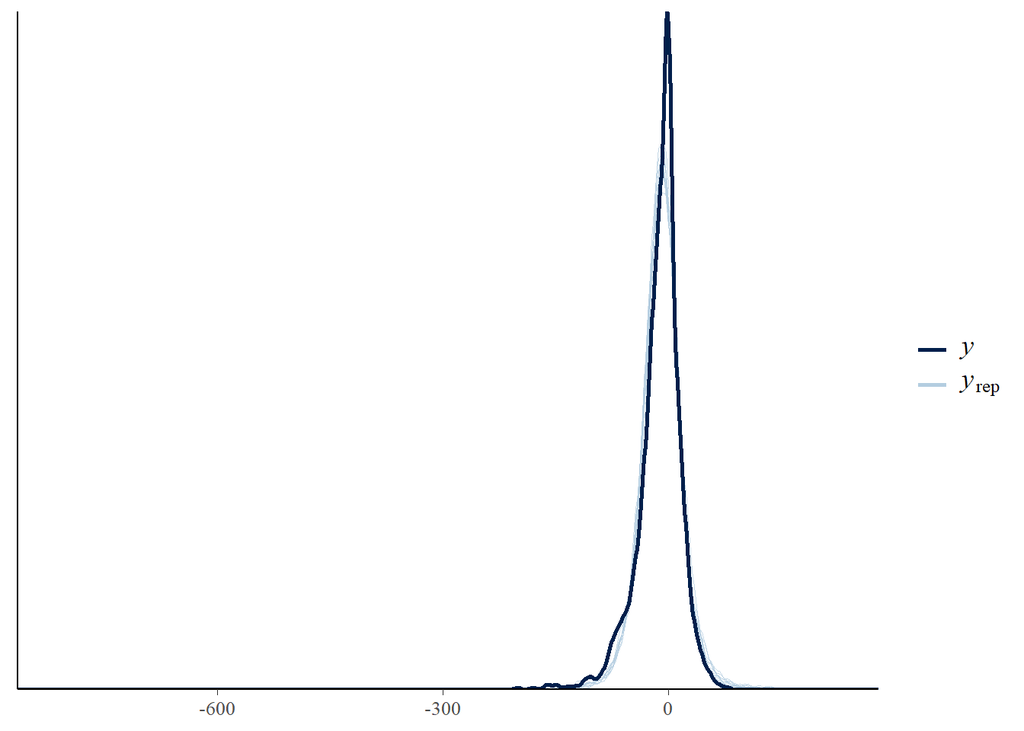

```r
pp_check(brm1_t)
```

However, we see that the t-distribution captures the real difference scores *much* better.

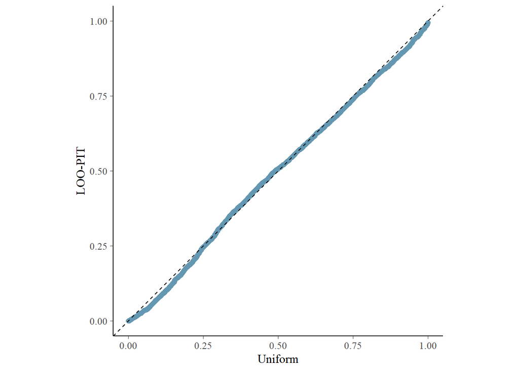

```r
pp_check(brm1_t, type = "loo_pit")
```

The qq-plot also looks better.

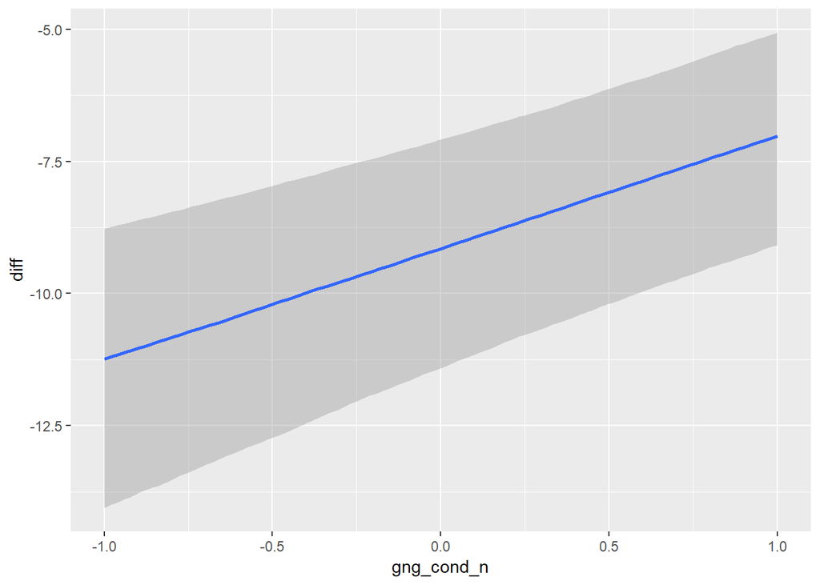

```r
marginal_effects(brm1_t)
```

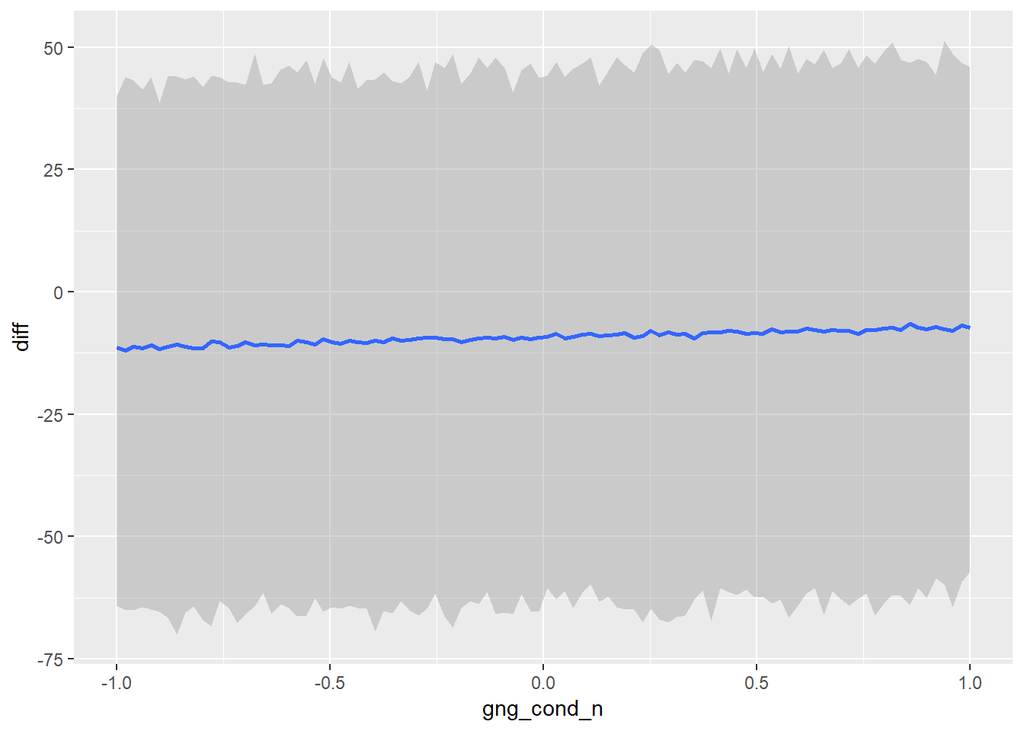

```r
marginal_effects(brm1_t, method = "predict")
```

These plots also look quite similar.

Lets compare the model with the previous Gaussian model in terms of predictive performance (`loo-ic`)

```r
loo_brm1_t <- loo(brm1_t)
loo_compare(loo_brm1, loo_brm1_t)
```

```
##        elpd_diff se_diff
## brm1_t    0.0       0.0
## brm1   -146.8      27.5
```

This is a ‘significant’ increase: Around 5 times the SE.

It is really worth trying these different model-families, they can sometimes make a big difference.